# GP_Evaluation2

Yuanxi Cheng

2022-09-09

## Evaluation of Player Population Vs Annual Median Household Income

### Map of Household Income

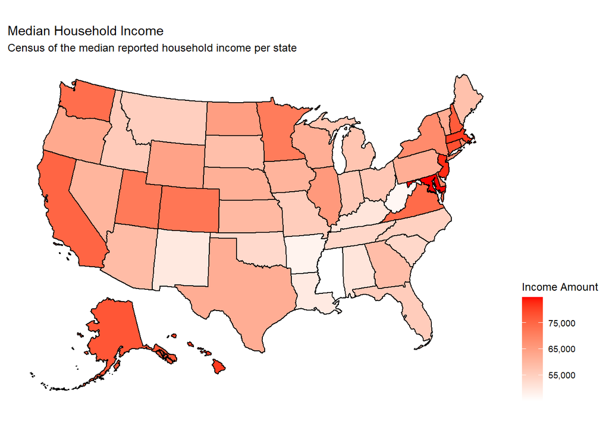

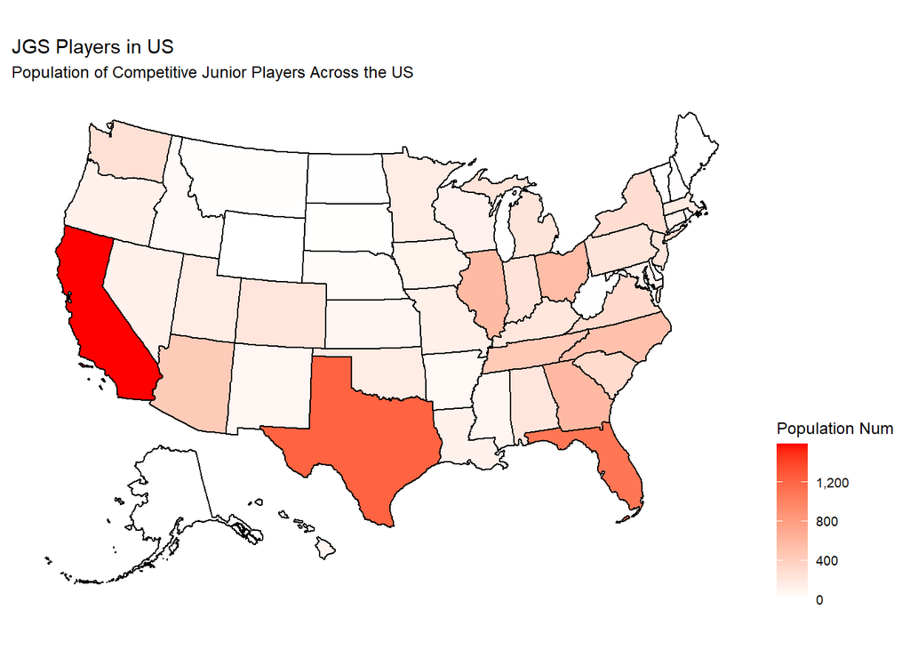

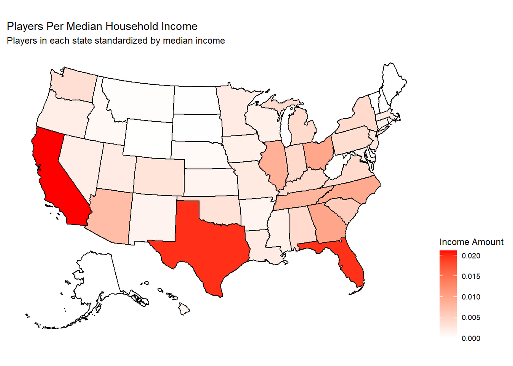

## Scatter Plots

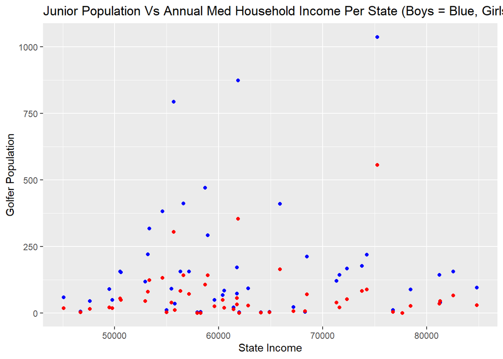

### Fitting Linear Models (Not Standardized Population)

### Boys:

#### Linear Regression Line

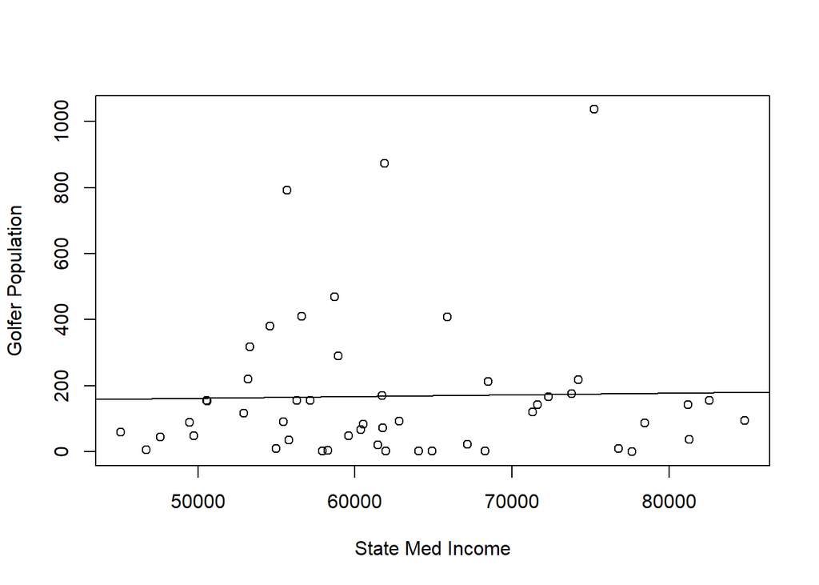

#### Analyzing Residuals and Testing Regression:

```
##
## Call:
## lm(formula = y ~ x, data = boysVsStateInc)
##
## Residuals:
##     Min      1Q  Median      3Q     Max
## -177.23 -138.58  -74.37    1.61  861.00
##
## Coefficients:
##              Estimate Std. Error t value Pr(>|t|)
## (Intercept) 1.376e+02  1.973e+02   0.697    0.489
## x           5.108e-04  3.109e-03   0.164    0.870
##
## Residual standard error: 223.9 on 48 degrees of freedom
## Multiple R-squared:  0.000562,   Adjusted R-squared:  -0.02026
## F-statistic: 0.02699 on 1 and 48 DF,  p-value: 0.8702
```

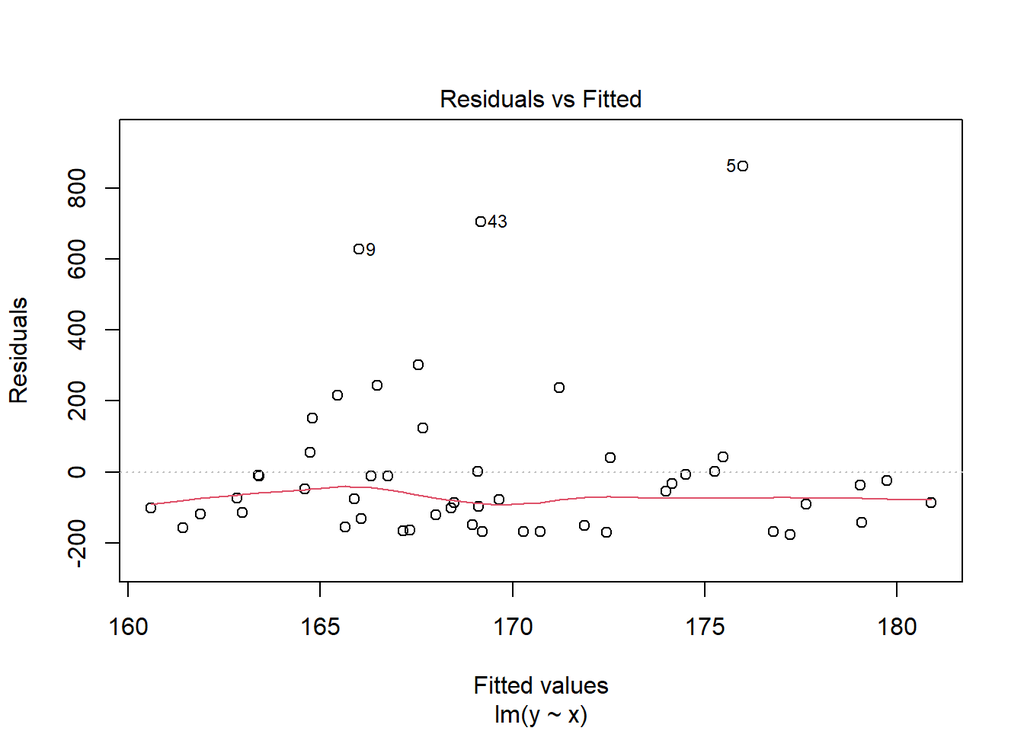

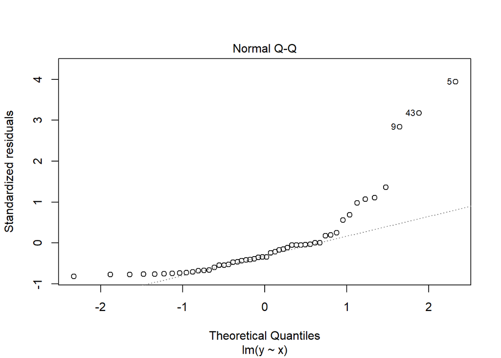

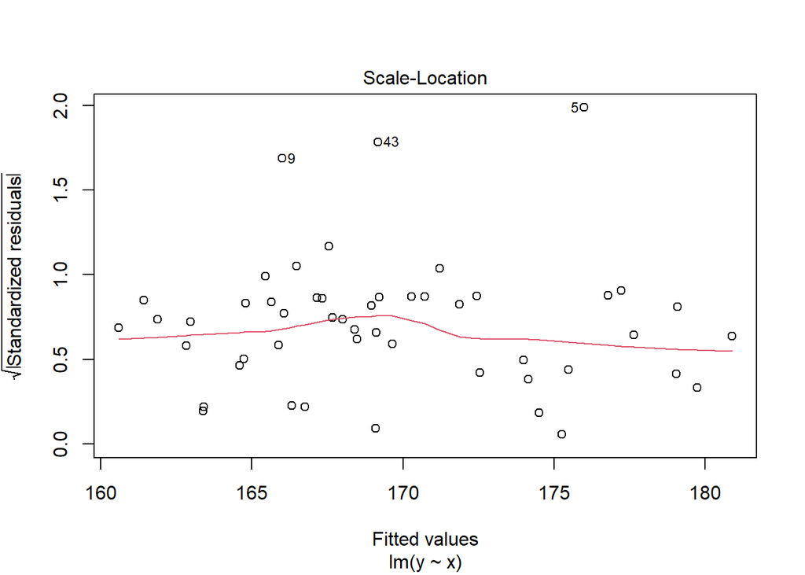

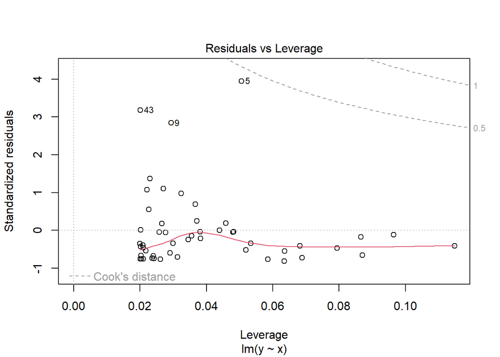

### Girls:

#### Linear Regression Line

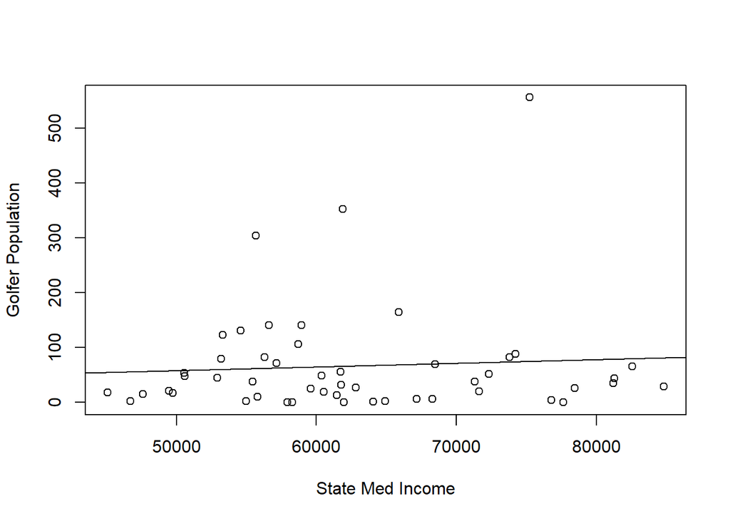

#### Analyzing Residuals and Testing Regression Girls:

```
##
## Call:
## lm(formula = y ~ x, data = girlsVsStateInc)
##
## Residuals:
##    Min     1Q Median     3Q    Max
## -76.11 -52.06 -34.22   8.44 481.48
##
## Coefficients:
##              Estimate Std. Error t value Pr(>|t|)
## (Intercept) 24.860188  88.516849   0.281    0.780
## x            0.000660   0.001395   0.473    0.638
##
## Residual standard error: 100.5 on 48 degrees of freedom
## Multiple R-squared:  0.004643,   Adjusted R-squared:  -0.01609
## F-statistic: 0.2239 on 1 and 48 DF,  p-value: 0.6382
```

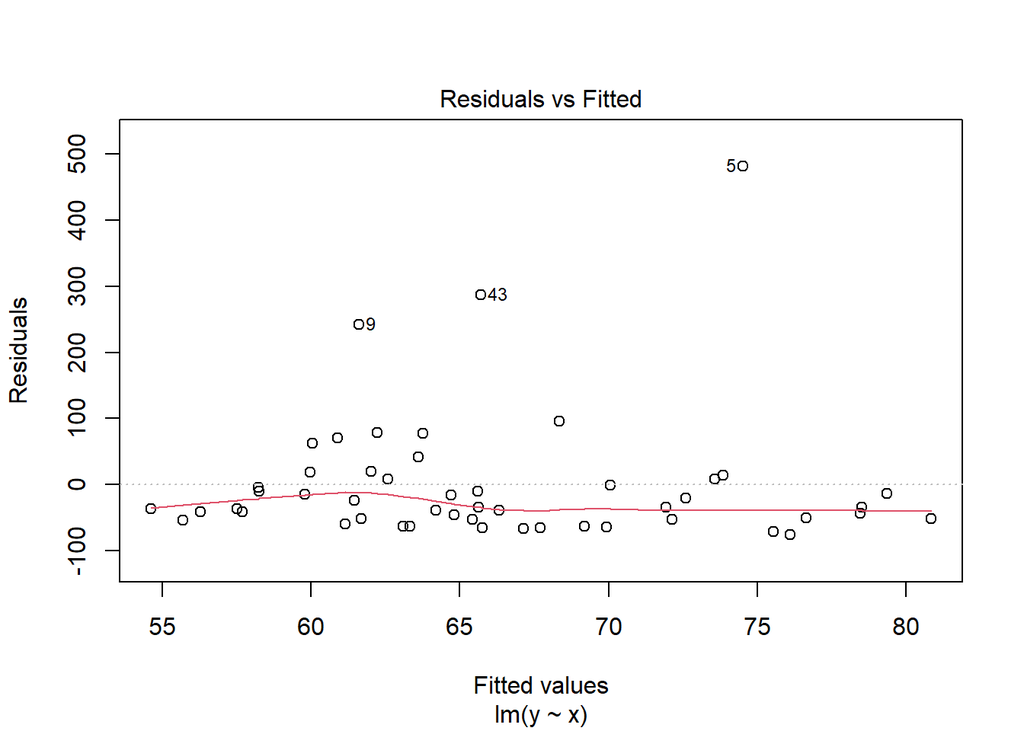

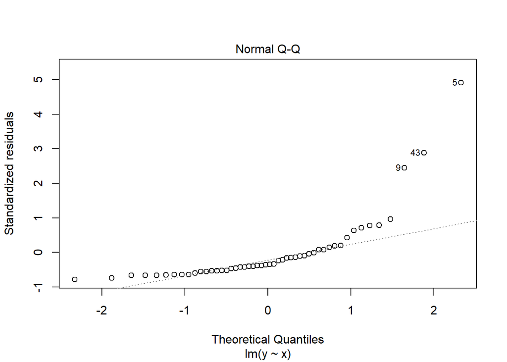

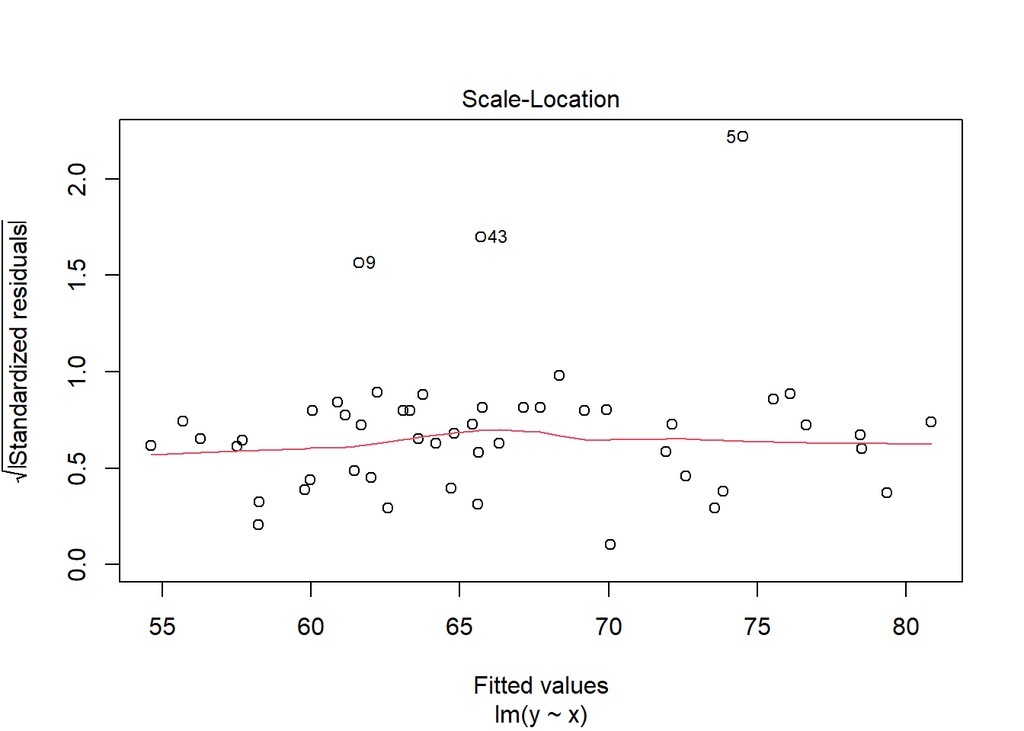

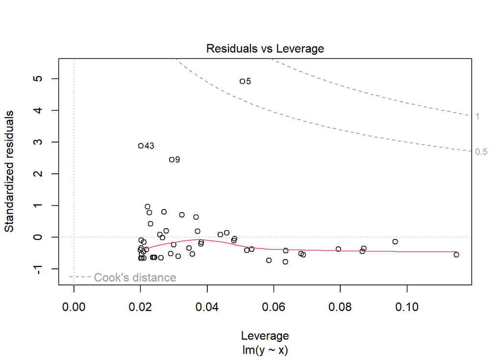